# HMWK2

# Prepared by Derek Chen, Justin Zipkin

### load data

```r
library(nycflights13)
nyc <- nycflights13::flights
```

### 1.

#### a) Explore airgain data and answer the question - do airlines actually gain any time when in air on average?

```r
nyc$airgain=nyc$dep_delay-nyc$arr_delay
average_airgain=mean(nyc$airgain,na.rm = TRUE)
```

##### The average air gain time is 5.6597789 mins, the positive value suggests that airlines actually gain time when in air on average

#### b) Calculate average airgain for different airlines.

```r
average_airgain_by_carrier=tapply(nyc$airgain, nyc$carrier, mean,na.rm=TRUE)
average_airgain_by_carrier=sort(average_airgain_by_carrier,decreasing = FALSE)
average_airgain_by_carrier
```

```
##         F9         FL         MQ         OO         US         YV
## -1.7195301 -1.5099213 -0.3293526  0.6551724  1.6150976  3.3419118
##         B6         EV         DL         WN         AA         UA
##  3.5095746  4.0424982  7.5796089  8.0125374  8.2048393  8.4588972
##         9E         VX         HA         AS
##  9.0599052 10.9921814 11.8157895 15.7616361
```

##### It seems like airline AS and HA gain most of the time in air, and F9 actually loses some time in air

#### c) Build a bar chart of average airgain for different airlines sorted by airgain. We want to graphically visualize which airlines are good at “catching up” when in air and which airlines actually lose time further after taking off.

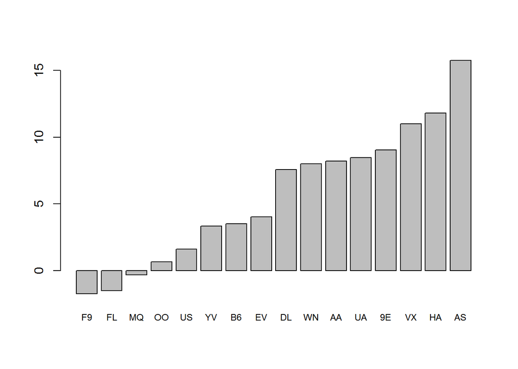

```r
barplot(average_airgain_by_carrier,cex.names=.75)
```

##### Only three airlines, MQ, FL, and F9 have a negative airgain time. The rest of airlines are good at catching up

### 2.

```r
sort(tapply(nyc$arr_delay, nyc$origin, mean,na.rm=TRUE),decreasing = TRUE)
```

```
##      EWR      LGA      JFK
## 9.107055 5.783488 5.551481
```

##### JFK airport has the least amount of arrival delay on average

### 3.

```r
optimal_airport_by_month=function(month_int){
  sort(tapply(nyc$arr_delay[nyc$month==month_int], nyc$origin[nyc$month==month_int], mean,na.rm=TRUE),decreasing = FALSE)[1]
}
optimal_june=optimal_airport_by_month(6)
```

##### The best airport to travel from in the month of June is LGA, with an average delay time of 14.7692779 minutes

### 4.

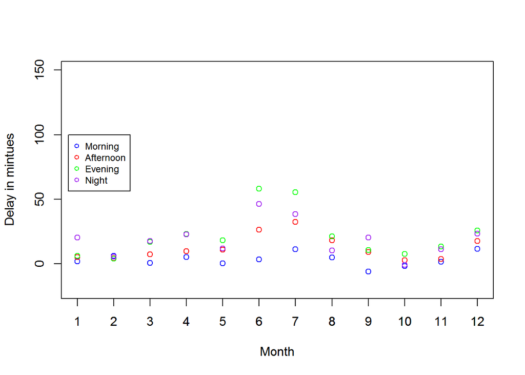

```r
average_delay_by_departing_time=function(departing_time_lower,departing_time_upper,dest_arp){

  if (departing_time_upper>departing_time_lower)
  {
    tapply(nyc$arr_delay[nyc$sched_dep_time>departing_time_lower &
                           nyc$sched_dep_time<=departing_time_upper&nyc$dest==dest_arp],
          nyc$month[nyc$sched_dep_time>departing_time_lower &
                      nyc$sched_dep_time<=departing_time_upper&nyc$dest==dest_arp],
           mean,na.rm=TRUE)}

  else {tapply(rbind(nyc[nyc$sched_dep_time>departing_time_lower & nyc$dest==dest_arp,],
                     nyc[nyc$sched_dep_time<=departing_time_upper & nyc$dest==dest_arp,])$arr_delay,
               rbind(nyc[nyc$sched_dep_time>departing_time_lower & nyc$dest==dest_arp,],
                     nyc[nyc$sched_dep_time<=departing_time_upper & nyc$dest==dest_arp,])$month,
               mean,na.rm=TRUE)}
}

morning_delay=average_delay_by_departing_time(400,1200,"ATL")
afternoon_delay=average_delay_by_departing_time(1200,1600,"ATL")
evening_delay=average_delay_by_departing_time(1600,2000,"ATL")
night_delay=average_delay_by_departing_time(2000,400,"ATL")

plot(morning_delay,col="blue",ylab="Delay in mintues",xlab="Month",ylim=c(-20,150))
points(afternoon_delay,col="red",ylab="",xaxt="n")
points(evening_delay,col="green",ylab="",xaxt="n")
points(night_delay,col="purple",ylab="",xaxt="n")
axis(1, at = seq(1, 12, by = 1), las=1)
legend(0.75,100,legend = c("Morning","Afternoon","Evening","Night"),col=c("blue","red","green","purple"),pch = 1,cex=.75)
```

### 5.

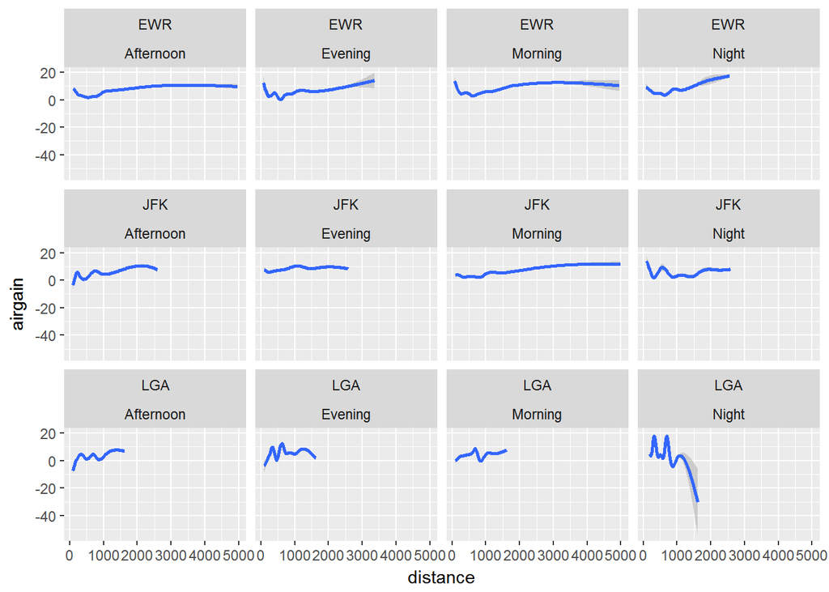

```r
library("ggplot2")
define_time_o_day=function(departing_time)
  {
    if (is.na(departing_time)){NA}
    else
      {
        if (departing_time<=1200&departing_time>400){"Morning"}
        else if (departing_time<=1600&departing_time>1200){"Afternoon"}
        else if (departing_time<=2000&departing_time>1600){"Evening"}
        else if (departing_time<=400) {"Night"}
        else if (departing_time>2000) {"Night"}
    }
}

v_def=Vectorize(define_time_o_day)
nyc$time.of.day=v_def(nyc$sched_dep_time)
ploting=subset(nyc[,c("distance","airgain","origin","time.of.day")],!is.na(time.of.day))
ggplot(data=subset(nyc[,c("distance","airgain","origin","time.of.day")],!is.na(time.of.day)),aes(distance,airgain))+
  geom_smooth()+
  facet_wrap(~origin+time.of.day,ncol=4)
```